# Homework 9 Responses

Zeyi Han, Shubhi Sharma, Margaret Swift

2020-04-22

## Exercise 1

*Select a species to fit. Use AIC as a model selection criterion to determine which combination of variables in `xdata` best fits the data.*

```
## Start:  AIC=10915.71
## y[, spec] ~ stdage + temp + deficit + stdage * temp + temp *
##     deficit + stdage * deficit + stdage * temp * deficit
##
##                       Df Deviance   AIC
## <none>                     8485.9 10916
## - stdage:temp:deficit  1   8503.6 10931
```

```
##
## Call:  glm(formula = y[, spec] ~ stdage + temp + deficit + stdage *
##     temp + temp * deficit + stdage * deficit + stdage * temp *
##     deficit, family = "poisson", data = xdata)
##
## Coefficients:
##         (Intercept)               stdage                 temp
##              0.6660              -1.4578               0.8725
##             deficit          stdage:temp         temp:deficit
##              3.0774               0.3299              -1.0283
##      stdage:deficit  stdage:temp:deficit
##             -1.8137               0.3228
##
## Degrees of Freedom: 1222 Total (i.e. Null);  1215 Residual
## Null Deviance:       31270
## Residual Deviance: 8486  AIC: 10920
```

```
## Start:  AIC=10931.37
## y[, spec] ~ stdage + temp + deficit + stdage * temp + temp *
##     deficit + stdage * deficit
##
##                  Df Deviance   AIC
## <none>                8503.6 10931
## - stdage:deficit  1   8553.4 10979
## - stdage:temp     1   8744.0 11170
## - temp:deficit    1  11069.2 13495
```

```
##
## Call:  glm(formula = y[, spec] ~ stdage + temp + deficit + stdage *
##     temp + temp * deficit + stdage * deficit, family = "poisson",
##     data = xdata)
##
## Coefficients:
##    (Intercept)          stdage            temp         deficit     stdage:temp
##         0.6426         -1.6639          0.8856          3.2260          0.4076
##   temp:deficit  stdage:deficit
##        -1.0849         -0.7959
##
## Degrees of Freedom: 1222 Total (i.e. Null);  1216 Residual
## Null Deviance:       31270
## Residual Deviance: 8504  AIC: 10930
```

```
## Start:  AIC=14034.34
## y[, spec] ~ stdage + temp + deficit
##
##           Df Deviance   AIC
## <none>          11612 14034
## - deficit  1    11628 14048
## - stdage   1    12607 15027
## - temp     1    19611 22031
```

```
##
## Call:  glm(formula = y[, spec] ~ stdage + temp + deficit, family = "poisson",
##     data = xdata)
##
## Coefficients:
## (Intercept)       stdage         temp      deficit
##      1.3232      -0.8200       0.5744      -0.1330
##
## Degrees of Freedom: 1222 Total (i.e. Null);  1219 Residual
## Null Deviance:       31270
## Residual Deviance: 11610     AIC: 14030
```

Based on the AIC for different model combinations. The full model with all three variables and all two way interaction and the three way interaction term best fits the data for species `LIST2`.

## Exercise 2

*Do you believe that the MCMC converged to a posterior distribution? If not, what might you do to convince yourself?*

## Exercise 3

*Divide up your group so that each determines how one of the following influences model selection. Use DIC as your criterion.*

*1. Different numbers of knots*

*2. Prior distributions on $\sigma^2$.*

*3. Prior distributions on $\phi$.*

| ModelName | knots | DIC |
| --- | --- | --- |
| 3a1 | 20 | -123181 |
| 3a2 | 30 | -123932 |
| 3a3 | 40 | -124462.4 |
| 3a4 | 50 | -123794.1 |

| ModelName | lo | hi | mu | sig |
| --- | --- | --- | --- | --- |
| 3b1 | 0.1 | 2 | 0.05 | 1 |
| 3b2 | 0 | 4 | 0.05 | 1 |
| 3b3 | 0 | 10 | 3 | 1 |
| 3d4 | 0 | 10 | 0.05 | 5 |

| ModelName | lo | hi | mu | sig |
| --- | --- | --- | --- | --- |
| 3c1 | 0 | 3 | 3 | 1 |
| 3c2 | 0 | 10 | 6 | 1 |
| 3c3 | 0 | 10 | 6 | 10 |
| 3c4 | 0 | 10 | 3 | 12 |

## Exercise 4

*Interpret the contributions of the mean and the spatial random effects to predicted surfaces. In other words, what do they mean?*

## Exercise 5

*Repeat exercise 3 with GJAM and compare results for the two models. If there are differences, can you explain them?*

## Exercise 6

*Repeat the spatial analysis with a binomial model. Use the `CARBayes` help page. Interpret the analysis.*

```
##
## #################
## #### Model fitted
## #################
## Likelihood model - Binomial (logit link function)
## Random effects model - BYM CAR
## Regression equation - y ~ x2 + x3
## Number of missing observations - 0
##
## ############
## #### Results
## ############
## Posterior quantities and DIC
##
##              Median    2.5%   97.5% n.effective Geweke.diag
## (Intercept) -1.4659 -1.5922 -1.3497       403.8         1.1
## x2          -1.7109 -1.8770 -1.5553       330.6         1.0
## x3          -0.0884 -0.2206  0.0540       439.3         0.2
## tau2         0.3758  0.1009  0.7696       119.8        -1.4
## sigma2       0.0072  0.0016  0.0649         8.6         3.2
##
## DIC =  544.5995       p.d =  41.93665       LMPL =  -275.37
```

In order to perform an analysis on a binomial model, we randomly generated vectors of (1) trial `sizes` using `rpois` with an arbitrary mean of 20 trials, (2) probability of success `p` using the inverse logit function (as binomial models use logit link), and (3) responses `y` using a binomial random variable `rbinom`. The true parameter values are contrasted with predicted in the table below:

True vs. predicted parameters.

|  | true | pred |
| --- | --- | --- |
| (Intercept) | -0.338 | -1.4659 |
| x2 | -1.676 | -1.7109 |
| x3 | -0.085 | -0.0884 |
| sigma2 | 0.100 | 0.0072 |

Since these data are re-generated randomly every time we knit this document, we cannot comment on particular values of predicted vs. true parameters. However, over a few different runs, we noticed that while `x2` and `x3` are predicted relatively well by this process, the intercept is often predicted to have the opposite sign from the true, and the variance `sigma2` is frequently predicted to be an order of magnitude smaller than the true value.

## Exercise 7

*Work through the lip cancer example in groups as if you were attempting to apply it to a data set of your own.*

The following are a few of our analytical notes on this example.

Summary Statistics

|  | observed | expected | pcaff | latitude | longitude |
| --- | --- | --- | --- | --- | --- |
|  | Min. : 0.000 | Min. : 1.100 | Min. : 0.000 | Min. :54.94 | Min. :1.430 |
|  | 1st Qu.: 4.750 | 1st Qu.: 4.050 | 1st Qu.: 1.000 | 1st Qu.:55.78 | 1st Qu.:3.288 |
|  | Median : 8.000 | Median : 6.300 | Median : 7.000 | Median :56.04 | Median :4.090 |
|  | Mean : 9.571 | Mean : 9.575 | Mean : 8.661 | Mean :56.40 | Mean :4.012 |
|  | 3rd Qu.:11.000 | 3rd Qu.:10.125 | 3rd Qu.:11.500 | 3rd Qu.:57.02 | 3rd Qu.:4.730 |
|  | Max. :39.000 | Max. :88.700 | Max. :24.000 | Max. :60.24 | Max. :6.800 |

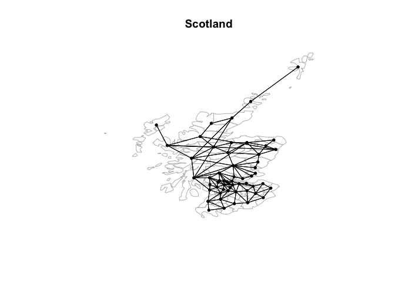

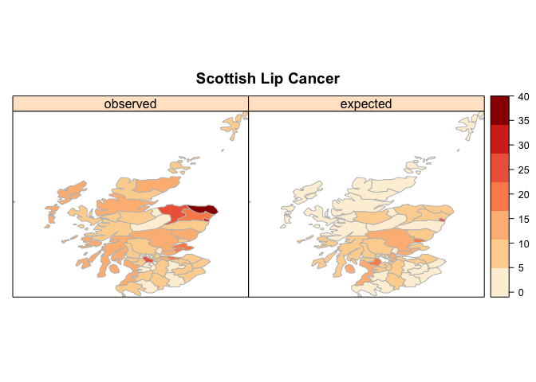

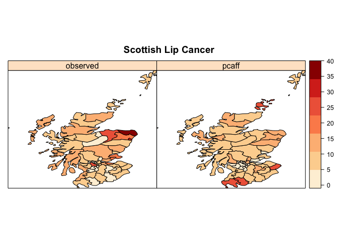

For this map, we can see the variable `pcaff` (percentage of workers in agriculture, fishing, and forestry) does not seem to be very closely related to lip cancer cases. As an interesting note, `pcaff` seems to be high along the Orkney islands.

95% Credible Intervals Model 1

|  | 0.5 | 0.025 | 0.975 |
| --- | --- | --- | --- |
| Intercept | -110.1820423 | -205.5997207 | -19.2803814 |
| Expected | 0.3462255 | 0.2224939 | 0.4744488 |
| Pcaff | 0.2016747 | -0.0641484 | 0.4552280 |
| Latitude | 2.1752145 | 0.5766688 | 3.8182550 |
| Longitude | -1.7121327 | -3.3908510 | 0.0162638 |

95% Credible Intervals Model 2

|  | 0.5 | 0.025 | 0.975 |
| --- | --- | --- | --- |
| Intercept | -12.4658737 | -25.2403547 | -0.1640820 |
| Expected | 0.0266294 | 0.0164385 | 0.0379276 |
| Pcaff | 0.0100455 | -0.0133073 | 0.0345803 |
| Latitude | 0.2602143 | 0.0472788 | 0.4909691 |
| Longitude | -0.1209620 | -0.3362772 | 0.0755061 |

95% Credible Model 3

|  | 0.5 | 0.025 | 0.975 |
| --- | --- | --- | --- |
| Expected | 0.0211555 | 0.0148062 | 0.0329970 |
| Pcaff | 0.0203602 | -0.0015029 | 0.0425945 |
| Latitude | 0.3400684 | 0.1574827 | 0.5063859 |
| Longitude | -0.1723372 | -0.2954158 | -0.0299346 |

Given the three models above, we can compare the DIC: 369, 315, and 289, respectively. Clearly, the third model has the lowest DIC and is the best fit to the data. This is likely because setting piecewise intercepts allows the model to more accurately conform to regional differences.

## Appendix

```r
#----------------------------------------------------------------------------
# LOADING
knitr::opts_chunk$set(echo=FALSE, eval=TRUE, cache=FALSE)
pacman::p_load(CARBayes, CARBayesdata, classInt, coda, fields, geomapdata, geoR, gjam, gtools, knitr, lattice, mapdata, maps, maptools, MASS, MBA, plyr, RANN, RColorBrewer, reshape2, rgdal, sp, spBayes, spdep)
source('../clarkfunctions2020.R')
# Rcpp::sourceCpp('../cppFns.cpp')
# any libraries and data here

#----------------------------------------------------------------------------
# FUNCTIONS
# put functions here

#----------------------------------------------------------------------------
## EXERCISE 1

load('../dataFiles/fiaSpBayes.Rdata')
xdata <- data.frame(x)
spec <- 'LIST2'
model1 <- glm(y[,spec] ~ stdage + temp + deficit + stdage*temp + temp*deficit + stdage*deficit + stdage*temp*deficit , data = xdata, family="poisson")
model2 <- glm(y[,spec] ~ stdage + temp + deficit + stdage*temp + temp*deficit + stdage*deficit , data = xdata, family="poisson")
model3 <- glm(y[,spec] ~ stdage + temp + deficit , data = xdata, family="poisson")

step(model1, direction = "both")
step(model2, direction = "both")
step(model3, direction = "both")

#----------------------------------------------------------------------------
## EXERCISE 3

# These data are hardcoded because running the model takes quite a bit of time.
a3 <- as.data.frame(cbind(ModelName = c("3a1", "3a2", "3a3", "3a4"),
                          knots = c(20, 30, 40, 50),
                          DIC = c(-123181, -123932 , -124462.4,  -123794.1)))
a4 <- as.data.frame(cbind(ModelName = c("3b1", "3b2", "3b3", "3d4"),
                          lo = c(0.1, 0, 0, 0), hi = c(2, 4, 10, 10),
                          mu =c(0.05, 0.05, 3, 0.05), sig =c(1, 1, 1, 5)))
a5 <- as.data.frame(cbind(ModelName = c("3c1", "3c2", "3c3", "3c4"),
                          lo = c(0, 0, 0, 0), hi = c(3, 10, 10, 10),
                          mu = c(3, 6, 6, 3), sig = c(1, 1, 10, 12)))
knitr::kable(a3)
knitr::kable(a4)
knitr::kable(a5)

#----------------------------------------------------------------------------
## EXERCISE 5

#----------------------------------------------------------------------------
## EXERCISE 6

# Existing simulation code **************************************************
m <- 12
n <- m^2
Q <- 3
sigma <- .1

xEast  <- xNorth <- 1:m
grid   <- expand.grid(xEast, xNorth)
D <- W <- as.matrix(dist(grid))
W[W!=1]<- 0

x     <- matrix( rnorm(Q*n), n, Q )
x[,1] <- 1; x2 <- x[,2]; x3 <- x[,3]
beta  <- matrix( rnorm(Q), Q, 1)
phi   <- mvrnorm(1, rep(0,n), 1*exp(-0.1*D) )
form  <- as.formula(y ~ x2 + x3)

# Binomial model ************************************************************
# Generate random no. of trials, mean 20; log-odds link for probabilities
sizes<- rpois(n=n, lambda=20)
p    <- inv.logit(x%*%beta + phi + rnorm(n, 0, sigma))
y    <- rbinom(length(phi), sizes, prob=p)

binomialModel <- S.CARbym(formula=form, family="binomial", trials=sizes,
                          W=W, burnin=600, n.sample=10000, thin=10, verbose=F)
binomialModel
dic <- round(binomialModel$modelfit[1])

df <- data.frame(true=c(round(beta, 3), sigma),
                 pred=binomialModel$summary.results[c(1:3,5),1])
kable(df, caption="True vs. predicted parameters.")

#----------------------------------------------------------------------------
## EXERCISE 7
data(lipdata)
data(lipdbf)
data(lipshp)
kable(summary(lipdata), caption="Summary Statistics")

lipdbf$dbf    <- lipdbf$dbf[ ,c(2,1)]
data.combined <- combine.data.shapefile(data=lipdata, shp=lipshp, dbf=lipdbf)

# map of neighbors
nb.bound <- poly2nb(data.combined)
coords   <- coordinates(data.combined)
plot(data.combined, border = "gray", main="Scotland")
plot(nb.bound, coords, pch = 19, cex = 0.6, add = TRUE)

# The map shows the neighbors. Here are maps of data:
breakpoints <- seq(min(lipdata$observed)-1, max(lipdata$observed)+1, length.out=8)
my.palette <- brewer.pal(n = 7, name = "OrRd")

spplot(data.combined, c("observed", "expected"),
       main="Scottish Lip Cancer",at=breakpoints,
       col.regions=my.palette, col="grey")
# Here is the pcaff variable, one of the predictors in the model:
spplot(data.combined, c("observed", "pcaff"),
       main="Scottish Lip Cancer", at=breakpoints,
       col.regions=my.palette, col="black")
# Linear model (GLM)
glmmodel <- glm(observed~., family="poisson", data=data.combined@data)
resid.glmmodel <- residuals(glmmodel)

W.nb    <- poly2nb(data.combined, row.names = rownames(data.combined@data))
W.list  <- nb2listw(W.nb, style="B")
testglm <- moran.mc(x=resid.glmmodel, listw=W.list, nsim=1000)
W       <- nb2mat(W.nb, style="B")
formula <- observed ~ expected+pcaff+latitude+longitude
model.spatial1 <- S.CARleroux(formula=formula,
                              data=data.combined@data,family="gaussian",
                              W=W, burnin=5000, n.sample=10000, thin=10, verbose=F)
betas1 <- summarise.samples(model.spatial1$samples$beta,
                            quantiles=c(0.5, 0.025, 0.975))
resultsMS1 <- betas1$quantiles
rownames(resultsMS1) <- c("Intercept", "Expected", "Pcaff", "Latitude", "Longitude")
kable(resultsMS1, caption="95% Credible Intervals Model 1")

# Nonlinear model
model.spatial2 <- S.CARleroux(formula=formula,
                              data=data.combined@data,family="poisson",
                              W=W, burnin=5000, n.sample=10000, thin=10, verbose=FALSE)
betas2 <- summarise.samples(model.spatial2$samples$beta, quantiles=c(0.5, 0.025, 0.975))
resultsMS2 <- betas2$quantiles
rownames(resultsMS2) <- c("Intercept", "Expected", "Pcaff", "Latitude", "Longitude")
kable(resultsMS2, caption="95% Credible Intervals Model 2")
# Here is another option with piecewise intercepts set by the constant G.
model.spatial3 <- S.CARlocalised(formula=formula, G=5,
                                 data=data.combined@data,family="poisson",
                                 W=W, burnin=5000, n.sample=10000, thin=10,
                                 verbose=FALSE)
betas3 <- summarise.samples(model.spatial3$samples$beta,
                            quantiles=c(0.5, 0.025, 0.975))
resultsMS3 <- betas3$quantiles
rownames(resultsMS3) <- c("Expected", "Pcaff", "Latitude", "Longitude")
kable(resultsMS3, caption="95% Credible Model 3")
dic1 <- round(model.spatial1$modelfit[['DIC']])
dic2 <- round(model.spatial2$modelfit[['DIC']])
dic3 <- round(model.spatial3$modelfit[['DIC']])
```